# Significance of Eplet Load in Liver Failure

Muhammad Sulman

Function to load data from file and some reformatting.

```r
load_data <- function(filepath){
  #save csv to variable
  df <- read.csv(filepath)

  #subtract 1 from age at transplant
  df$Age.at.Transplant <- df$Age.at.Transplant - 1

  #add donor age
  df$Donor.DOB <- mdy(df$Donor.DOB)
  df$Date.Anesthesia.Start <- mdy(df$Date.Anesthesia.Start)
  df$Donor.Age <- as.numeric(df$Date.Anesthesia.Start - df$Donor.DOB, units="days")

  #Adds Time to Graft failure and status column
  df$Date.of.Graft.Failure <- mdy(df$Date.of.Graft.Failure)
  df$status <- ifelse(is.na(df$Date.of.Graft.Failure), 0 , 1)
  df$Time <- as.numeric(df$Date.of.Graft.Failure - df$Date.Anesthesia.Start, units="days")
  df <- df %>% filter(Time>0)

  #when the function is called, return the dataframe
  return(df)
}
```

Load data and save to a variable

```r
df <- load_data("data/liver_data.csv")
```

Saves the name of independent variable columns, including HLA and clinical factors, to a vector

```r
HLA_vars <- c("HLA.A.Epitope.Mismatch.No.",
              "HLA.B.Epitope.Mismatch.No.",
              "HLA.C.Epitope.Mismatch.No.",
              "HLA.DRB1.Epitope.Mismatch.No.",
              "HLA.DRB345.Epitope.Mismatch.No.",
              "HLA.DP.Epitope.Mismatch.No.",
              "HLA.DQ.Epitope.Mismatch.No.")

#Donor age is missing data, as such, may cause issues. Two variables created, one with and one without Donor age.
clin_vars1 <- c("Number.of.Transplant",
                "BMI.of.Recipient",
                "Age.at.Transplant")

#with Donor Age
clin_vars2 <- c("Number.of.Transplant",
                "BMI.of.Recipient",
                "Age.at.Transplant",
                "Donor.Age")

#all independant variables
indep_vars1 <- c(HLA_vars, clin_vars1)
indep_vars2 <- c(HLA_vars, clin_vars2)

#all variables, including Time, the dependant variable
all_vars1 <- c(indep_vars1, "Time", "status")
all_vars2 <- c(indep_vars2, "Time", "status")
```

Simplified data frames with relevant variables

```r
df_short1 <- df[all_vars1] %>% na.omit()
df_short2 <- df[all_vars2] %>% na.omit()
```

Make a correlation plot of all variables

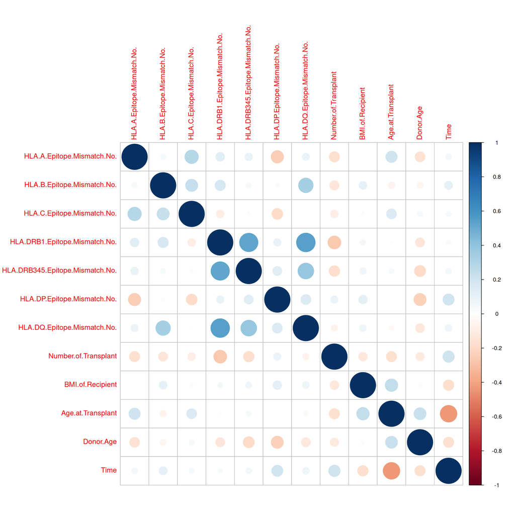

```r
#Note that age at transplant and Time negatively associate. DQ, DRB and DP also associate (likely proximal DNA regions, therefore lack of rearrangement)
df_short2 %>% subset(select = -status) %>% cor() %>% corrplot()
```

Function for creating survival curves for every independant variable after stratifying by “high” (above median) and “low” (Below medium).

```r
plot_surv_and_logrank <- function(data, independent_vars, status_var, time_var) {
  results <- list()

  for (var in independent_vars) {
    data[[var]] <- ntile(data[[var]], 2) # Ensure data is modified by reference
    fit_formula <- as.formula(paste0("Surv(", time_var, ", ", status_var, ") ~ ", var))
    fit <- surv_fit(fit_formula, data = data)
    p <- ggsurvplot(
      fit,
      data = data,
      xlab = "Time",
      ylab = "Survival probability",
      palette = c("#4DAD5B","#FC4E07"),
      conf.int = FALSE,
      surv.scale = "percent",
      legend.labs = c(paste0("Low ", var), paste0("High ", var)) # Update legend labels
    )

    log_rank_result <- survdiff(fit_formula, data = data)

    # Store results
    results[[var]] <- list(plot = p, log_rank_result = log_rank_result)
    cat("Log-rank test result for", var, ":\n")
    print(log_rank_result)
    print(p)

    ggsave(paste0("img/", var, ".svg"), plot = p$plot)
  }

  return(results)
}
```

Call function and draw survival function for high (above median) and low of each independent variable. log rank tests are performed.